# Experimental Design and Probability

## Review: one-way ANOVA

Completely randomized design

- treatments are assigned completely at random to experimental units
- simplest type of design

\[ \begin{aligned} y_{ij} = \mu + A_i + \epsilon_{ij} \\ \epsilon_{ij} \sim N(0, \sigma^2) \end{aligned} \]

- \(\mu\) = population mean across treatments
- \(A\) = treatment A, with levels \(i\) (fixed effects)

## Randomized complete blocks (RCB)

Historical roots of RCB: agricultural experiments

Field plots differ in lots of ways: how to minimize the effects of ‘nuisance’ variables?

Use a blocked design! RCB is the simplest kind of blocked design.

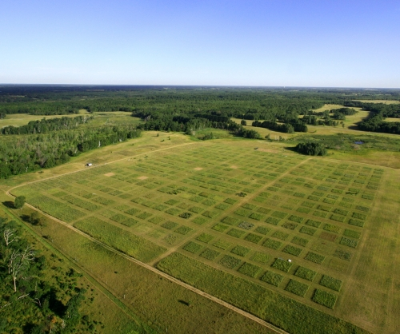

## RCB ANOVA: example

How does fish abundance affect the abundance and diversity of zooplankton prey?

Treatment: fish abundance

- control (no cage)
- low (30 small fish in 3x3m cage)
- high (90 small fish in 3x3m cage)

Block: location in lake (n = 5)

- one replicate of each treatment was set up in each location

Response: Levins’ \(D\) (index of richness and abundance)

## Load the data

```r
# Packages
library(tidyverse)
library(broom)
theme_set(theme_bw(base_size = 14) +
            theme(panel.grid = element_blank()))

# Set the web address where R will look for files from this repository
repo_url <- "https://raw.githubusercontent.com/elahi/xdp/master/data/"
dat <- read_csv(paste(repo_url,
                      "chap18e2ZooplanktonDepredation.csv",
                      sep = ""))
```

## Examine data

Do you see a problem?

```r
str(dat)
```

```
## Classes 'spec_tbl_df', 'tbl_df', 'tbl' and 'data.frame': 15 obs. of  3 variables:
##  $ treatment: chr  "control" "low" "high" "control" ...
##  $ diversity: num  4.1 2.2 1.3 3.2 2.4 2 3 1.5 1 2.3 ...
##  $ block    : num  1 1 1 2 2 2 3 3 3 4 ...
##  - attr(*, "spec")=
##   .. cols(
##   ..   treatment = col_character(),
##   ..   diversity = col_double(),
##   ..   block = col_double()
##   .. )
```

## Change *block* to a factor

Also, reorder the levels in treatment to be sensible:

```r
dat <- dat %>%
  mutate(block = as.factor(block),
         treatment = factor(treatment,
                            levels = c("control", "low", "high")))
levels(dat$treatment)
```

```
## [1] "control" "low"     "high"
```

[output not shown]

## RCB model

response ~ treatment + block + error

\[ \begin{aligned} y_{ij} = \mu + A_i + B_j + [AB_{ij}] + \epsilon_{ij} \\ \end{aligned} \]

- \(\mu\) = population mean across treatments
- \(A\) = treatment A, with levels \(i\)
- \(B\) = block B, with levels \(j\)
- \([AB_{ij}]\) = **treatment:block interaction, assumed to be 0**

In RCB design, each treatment level is represented in each block **once**.

Hence, this design is considered a *two-way ANOVA without replication*

## Assumptions of RCB model

- Errors \(\epsilon_{ij}\) are independent, have equal variance, and a normal distribution
- Additivity: treatment differences are the same for every block and the block differences are the same for every treatment. *No interactions*.
- ANOVA and F-test assume *balanced* data

## Visualize data to check for *additivity*

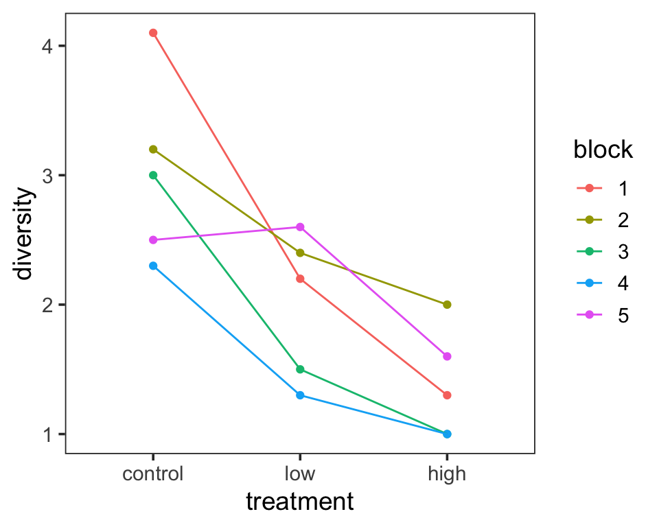

```r
dat %>%
  ggplot(aes(treatment, diversity, color = block, group = block)) +
  geom_point() + geom_path()
```

Additivity should show up as parallel block trends between treatments.

Linear model with blocking term

\[ \begin{aligned} \text{diversity} = \mu + \text{block} + \text{treatment} + \epsilon \\ \end{aligned} \]

```r
m0 <- lm(diversity ~ 1, data = dat)
m1 <- lm(diversity ~ block, data = dat)
m2 <- lm(diversity ~ block + treatment, data = dat)
anova(m0)
anova(m1)
anova(m2)
```

Write out, in words, the numerator and denominator for each F-value for `m1` and `m2`.

What does the rule for calculating the F-value using `anova` appear to be?

## Visualizing null vs ANOVA model

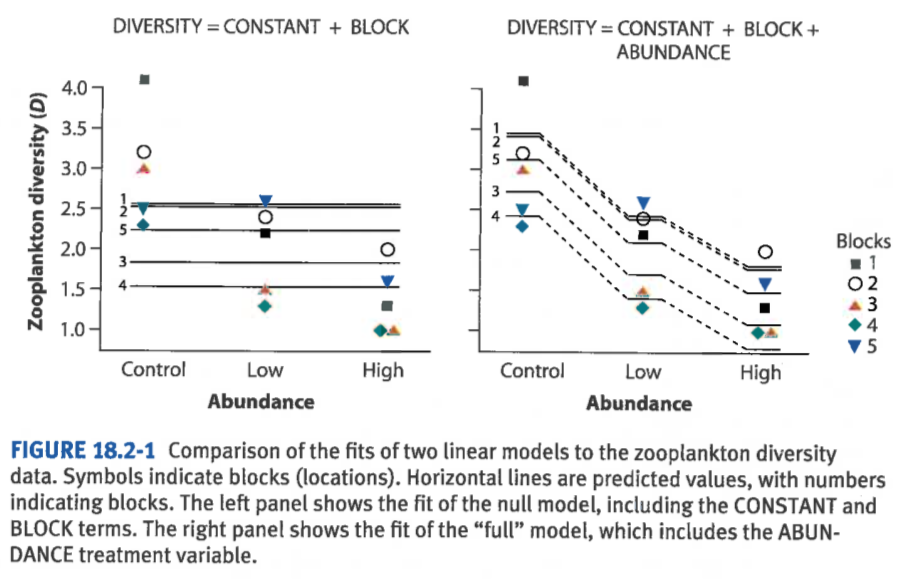

## Model diagnostics

Check that residuals

- have a nearly normal distribution
- no pattern (trend, unequal variance) across blocks
- no pattern (trend, unequal variance) across treatments

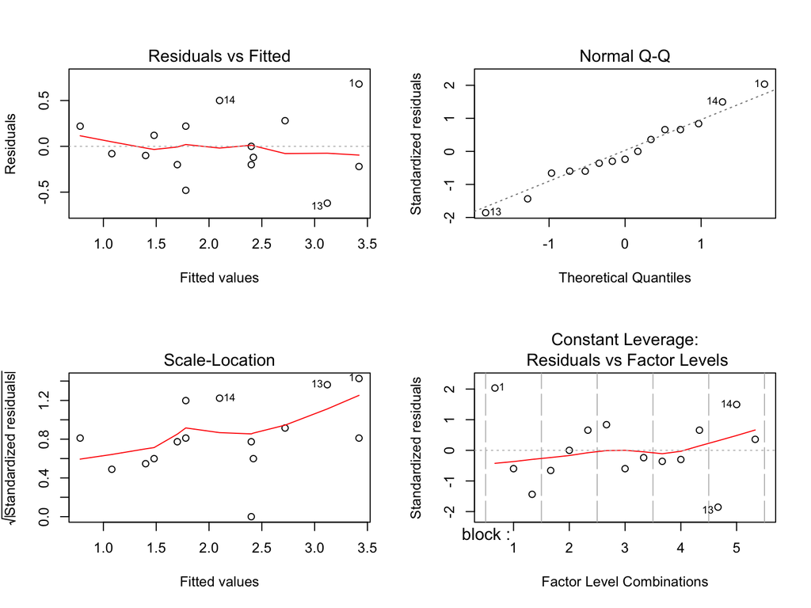

```r
par(mfrow = c(2,2)); plot(m2)
```

## If you need unplanned comparisons, use `aov`

```r
aov1 <- aov(diversity ~ block + treatment, data = dat)
summary(aov1)
TukeyHSD(aov1)
```

What do the unplanned comparisons tell you?

## What if we remove (inappropriately) the block effect?

```r
m3 <- lm(diversity ~ treatment, data = dat)
anova(m2)
anova(m3)
```

Inspect the sums of squares for *treatment* and *residuals* in both models; do the same for the *treatment* f-value.

What does this tell you about the *block* term in the model?

## Exercise

Run the models, and answer the questions in slides 12, 16, 17.

Run one more model, but rearrange the order of block and treatment in the model specification. Do your results change?

```r
m4 <- lm(diversity ~ treatment + block, data = dat)
```